# DVR_Project3

Aura Maria Salazar, Adriana Murga

October 16, 2015

In this project we were given the task to find several data sets (csv files) that can be joined and that we are interested in. This project then shows the data we chose as well as interesting visualizations we created from joins of these data sets.

# The Steps

## Step 1

The first step to produce our project was to look for the data. We used 4 CSV files for this project. The first one included data from the GDP of each state. This file contained information about the revenue, debt, gross state product, real estate growth, and population of each state in the United States. The second csv file (Book1.csv) included data from unemployment levels at different states. The column names in this file included state name, number of population employed, number of population unemployed both in numbers and percentages of entire population. The third file (Medicare Hospital Spending by Claim.csv) had information of different hospitals through different states in the United States. It includes information about the spending per hospital, per state and national as well. Finally, our last file was a simple table of state names and it corresponding abbreviation (StateAbbr.csv) which we used in order to be able to join our different tables.

### Step 2

Once we selected our data we begun to set up the data to create the oracle tables. We modified the R_ETL.R. file to load our csv files into our oracle dtabase. These files can be found under the folder named 01 Data with the names starting with ‘Set up.’

```r
source("../01 Data/Summary_Data_GDP.R", echo = TRUE)
```

```
##
## > require("jsonlite")
```

```
##
## > require("RCurl")
```

```
##
## > require("dplyr")
```

```
##
## > df2 <- data.frame(fromJSON(getURL(URLencode("129.152.144.84:5001/rest/native/?query=\"select * from USGS_STATE_2010\""),
## +     httpheader = c(DB =  .... [TRUNCATED]
##
## > summary(df2)
##                  STATE         DEBT          REVENUE
##  ALABAMA            : 1   Min.   : 3904   Min.   : 6089
##  ALASKA             : 1   1st Qu.: 6647   1st Qu.: 6752
##  ALL STATES COMBINED: 1   Median : 7853   Median : 7526
##  ARIZONA            : 1   Mean   : 8453   Mean   : 8168
##  ARKANSAS           : 1   3rd Qu.: 9786   3rd Qu.: 8700
##  CALIFORNIA         : 1   Max.   :17069   Max.   :17336
##  (Other)            :46
##  GROSS_STATE_PRODUCT REAL_STATE_GROWTH_ POPULATION_MILLION_
##  Min.   :   26.50    Min.   :-2.200     Min.   :  0.600
##  1st Qu.:   79.92    1st Qu.: 1.300     1st Qu.:  1.750
##  Median :  183.95    Median : 2.200     Median :  4.400
##  Mean   :  573.73    Mean   : 2.252     Mean   : 11.898
##  3rd Qu.:  389.48    3rd Qu.: 2.975     3rd Qu.:  7.025
##  Max.   :14964.40    Max.   : 7.400     Max.   :309.300
##
```

### Data of Unemployment

```r
source("../01 Data/Summary_Data_Unemployed.R", echo = TRUE)
```

```
##
## > require("jsonlite")
##
## > require("RCurl")
##
## > df1 <- data.frame(fromJSON(getURL(URLencode("129.152.144.84:5001/rest/native/?query=\"select * from Unemployed\""),
## +     httpheader = c(DB = "jdbc ..." ... [TRUNCATED]
##
## > summary(df1)
##         STATE                                AGROUP     STATE_FIPS_CODE
##  CALIFORNIA:  66   Married men, spouse present  :  51   Min.   : 1.00
##  NEW YORK  :  65   Married women, spouse present:  51   1st Qu.:16.00
##  FLORIDA   :  64   Men                          :  51   Median :28.00
##  ILLINOIS  :  63   Men, 20 to 24 years          :  51   Mean   :28.59
##  TEXAS     :  63   Men, 25 to 34 years          :  51   3rd Qu.:41.00
##  MARYLAND  :  62   Men, 35 to 44 years          :  51   Max.   :56.00
##  (Other)   :2191   (Other)                      :2268
##    GROUP_CODE    CIVILIAN_NON_INST_POPULATION    ANUMBER
##  Min.   : 1.00   Min.   :    5.0              Min.   :    3.0
##  1st Qu.:15.00   1st Qu.:  107.0              1st Qu.:   64.0
##  Median :28.00   Median :  283.0              Median :  163.5
##  Mean   :28.68   Mean   :  759.2              Mean   :  481.8
##  3rd Qu.:41.00   3rd Qu.:  727.5              3rd Qu.:  463.0
##  Max.   :67.00   Max.   :30158.0              Max.   :18797.0
##
##  PERCENT_OF_POPULATION NUMBEREMPLOYED     POP_EMPLOYED   NUMBERUNEMPLOYED
##  Min.   :11.40         Min.   :    3.0   Min.   :10.80   Min.   :  -3.00
##  1st Qu.:58.50         1st Qu.:   58.0   1st Qu.:54.00   1st Qu.:   4.00
##  Median :69.80         Median :  153.0   Median :64.80   Median :  11.00
##  Mean   :65.39         Mean   :  452.8   Mean   :60.98   Mean   :  28.95
##  3rd Qu.:78.90         3rd Qu.:  434.5   3rd Qu.:74.58   3rd Qu.:  27.00
##  Max.   :94.70         Max.   :17391.0   Max.   :91.90   Max.   :1406.00
##
##   RATEUNEMPLO
##  Min.   :-3.000
##  1st Qu.: 3.925
##  Median : 5.450
##  Mean   : 7.171
##  3rd Qu.: 8.600
##  Max.   :37.300
##
```

### Data of Medicare Spending

```r
source("../01 Data/Summary_Data_Medicare.R", echo = TRUE)
```

```
##
## > df5 <- data.frame(fromJSON(getURL(URLencode("129.152.144.84:5001/rest/native/?query=\"select * from MEDICARE\""),
## +     httpheader = c(DB = "jdbc:o ..." ... [TRUNCATED]
##
## > summary(df5)
##                  HOSPITAL_NAME       STATE
##  MEMORIAL HOSPITAL      :  176   TX     : 6490
##  GOOD SAMARITAN HOSPITAL:  154   CA     : 6424
##  MERCY HOSPITAL         :  132   FL     : 3674
##  ST MARYS HOSPITAL      :  132   PA     : 3300
##  MERCY MEDICAL CENTER   :  110   NY     : 3256
##  ST JOSEPH HOSPITAL     :  110   OH     : 2816
##  (Other)                :69784   (Other):44638
##                                                              PERIOD
##  1 through 30 days After Discharge from Index Hospital Admission:22463
##  1 to 3 days Prior to Index Hospital Admission                  :22463
##  Complete Episode                                               : 3209
##  During Index Hospital Admission                                :22463
##
##
##
##                      CLAIM_TYPE    PROVIDER_NUMBER
##  Carrier                  : 9627   Min.   : 10001
##  Durable Medical Equipment: 9627   1st Qu.:110109
##  Home Health Agency       : 9627   Median :260025
##  Hospice                  : 9627   Mean   :262747
##  Inpatient                : 9627   3rd Qu.:390147
##  Outpatient               : 9627   Max.   :670098
##  (Other)                  :12836
##  AVGSPENDINGPEREPISODE_HOSPI_ AVGSPENDPEREPISODE_ST_
##  Min.   :    0                Min.   :    0
##  1st Qu.:    0                1st Qu.:    2
##  Median :   66                Median :   95
##  Mean   : 1687                Mean   : 1821
##  3rd Qu.:  929                3rd Qu.: 1075
##  Max.   :39448                Max.   :22151
##
##  AVGSPENDPEREPISODE_NAT_ PERCENTSPEND_HOSP_ PERCENTSPEND_ST_
##  Min.   :    0           Min.   :  0.000    Min.   :  0.000
##  1st Qu.:    2           1st Qu.:  0.000    1st Qu.:  0.010
##  Median :  109           Median :  0.360    Median :  0.480
##  Mean   : 1820           Mean   :  9.091    Mean   :  9.091
##  3rd Qu.: 1083           3rd Qu.:  5.190    3rd Qu.:  5.370
##  Max.   :20025           Max.   :100.000    Max.   :100.000
##
##  PERCENTSPEND_NAT_   START_DATE        END_DATE
##  Min.   :  0.00    Min.   :112014   Min.   :12312014
##  1st Qu.:  0.01    1st Qu.:112014   1st Qu.:12312014
##  Median :  0.54    Median :112014   Median :12312014
##  Mean   :  9.09    Mean   :112014   Mean   :12312014
##  3rd Qu.:  5.41    3rd Qu.:112014   3rd Qu.:12312014
##  Max.   :100.00    Max.   :112014   Max.   :12312014
##
```

### Data of States’ Abbreviation

```r
source("../01 Data/Summary_Data_States.R", echo = TRUE)
```

```
##
## > df4 <- data.frame(fromJSON(getURL(URLencode("129.152.144.84:5001/rest/native/?query=\"select * from STATESABBR\""),
## +     httpheader = c(DB = "jdbc ..." ... [TRUNCATED]
##
## > summary(df4)
##         STATE     ABBREVIATION
##  ALABAMA   : 1   AK     : 1
##  ALASKA    : 1   AL     : 1
##  ARIZONA   : 1   AR     : 1
##  ARKANSAS  : 1   AZ     : 1
##  CALIFORNIA: 1   CA     : 1
##  COLORADO  : 1   CO     : 1
##  (Other)   :45   (Other):45
```

## Step 3

Once we had our data in place, with the tables created in Oracle, we continued by playing around with it and creating the joins required for this project. You can find our data wranglings in the folder 02 Data Wrangling.

The first data wrangling we created can be found in the file ‘DataWrangling1.R’ shown below. In this file we joined the Unemployment data (df1) with the GDP per state Data(df2) by ‘STATE’. We created a new table that used the ‘AGROUP’ and ‘RATEUNEMPLO’ from the Unemployment table, and the ‘Revenue’ from the GDP table.

```r
source("../02 Data Wrangling/DataWrangling1.R", echo=TRUE)
```

```
##
## > require("jsonlite")
##
## > require(dplyr)
##
## > dr1 <- dplyr::inner_join(df1, df2, by = "STATE")
```

```
##
## > tmp <- dr1
##
## > dw1 <- tmp %>% select(STATE, AGROUP, RATEUNEMPLO,
## +     REVENUE) %>% filter(AGROUP %in% c("Women", "Men")) %>% arrange(desc(STATE))
##
## > dw1
##                    STATE AGROUP RATEUNEMPLO REVENUE
## 1                WYOMING    Men         4.1 14076.5
## 2                WYOMING  Women         4.7 14076.5
## 3              WISCONSIN    Men         5.8  9747.6
## 4              WISCONSIN  Women         5.5  9747.6
## 5          WEST VIRGINIA    Men         7.8  6679.4
## 6          WEST VIRGINIA  Women         5.2  6679.4
## 7             WASHINGTON    Men         7.2  8758.7
```

[output cut: 95 more lines]

## Step 4

We then created a visualization for this data called ‘Visualization1.R’ Inthis visualization we generated a graph to see what the relationship between the state’s revenue and the state’s unemployment rate was, as well as if there was any difference between that relationship for men and for women. The graph was surprising in that it does not show a clear correlation between the state’s revenue and the unemployment rate. The unemployment rate seems steady regardless of the revenue that the state is generating. On the other hand, the data does not show a significant difference between men and women’s unemployment rates.

```r
source("../03 Visualization/Visualization1.R", echo=TRUE)
```

```
##
## > require("ggplot2")
```

```
##
## > require(extrafont)
```

```
## Registering fonts with R
```

```
##
## > ggplot() + coord_cartesian() + scale_x_continuous() +
## +     scale_y_continuous() + facet_grid(. ~ AGROUP, labeller = label_both) +
## +     labs(titl .... [TRUNCATED]
```

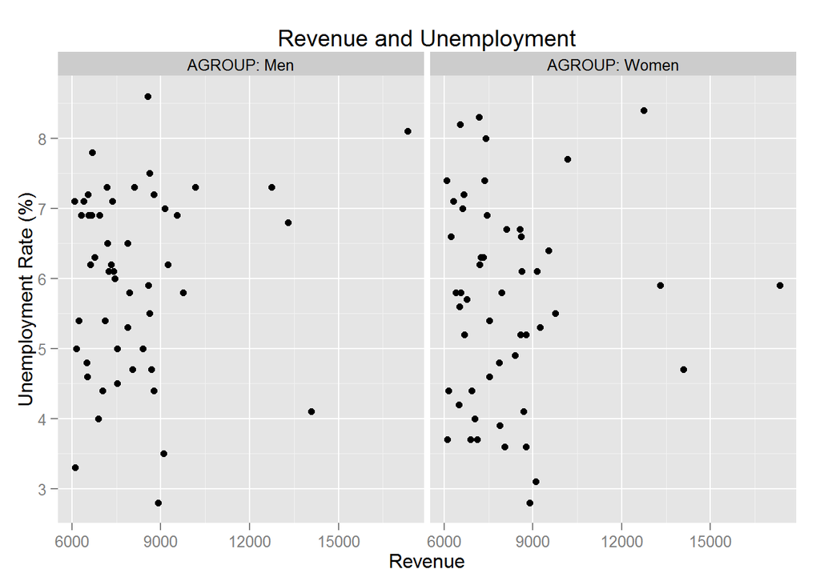

## Step 5

```r
source("../02 Data Wrangling/DataWrangling2.R", echo=FALSE)
```

```r
source("../03 Visualization/Visualization2.R", echo=TRUE)
```

```
##
## > ggplot(data = dw2, aes(x = population, y = num_hospitals)) +
## +     geom_point(size = 4, shape = 21, fill = "blue", colour = "blue") +
## +     labs(t .... [TRUNCATED]
```

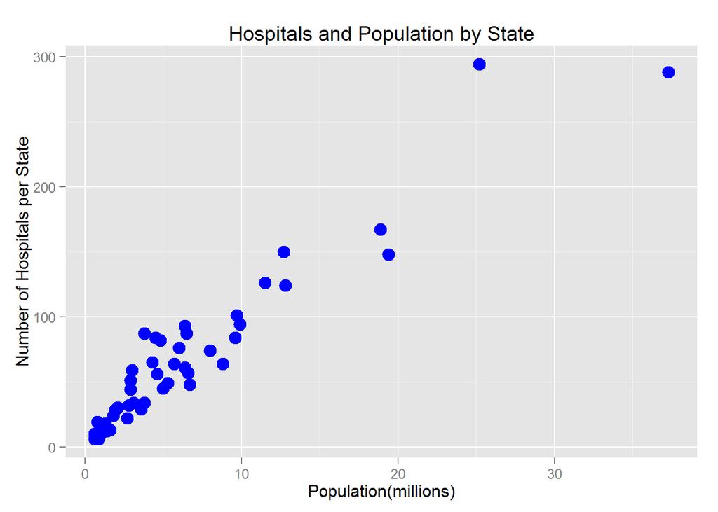

## Step 6

Here’s our third data wrangling. In this step we combined the data for Medicare and Unemployment. Since the Unemployment data had the full name of states while the Medicare data had the states’ abbreviation we had to first join the Medicare and the States Abbreviation data sets. Once we created that join (dr4) we decided to modify the data from the Unemployed data set to show only the AGROUP total amounts so that when we did a full join between this new data frame and the Medicare table every row of the table would show the Hospital, the location and the data for the totality of that state’s employment rate. Our final data frame is dr5 which is simple words is an outer join between Medicare and Unemployed data sets.

```r
source("../02 Data Wrangling/DataWrangling3.R", echo=FALSE)
```

To do our visualizations, we decided to build three different ones for it to be clearer how we compared everything. On the first one we show the states and the population that is employed in every state. The second one shows the number of hospitals per state and finally the last ones compares population employed and number of hospitals. We decided to make this comparison because we thought that it might be interesting to see if more people were unemployed there would be less hospitals for less people could actually afford a health plan, but surprisingly there is almost no correlation between these two factors. The number of hospitals doesnt seem to be affected by number of the population employed so our initial hypothesis was wrong.

```r
source("../03 Visualization/Visualization3(1).R", echo=TRUE)
```

```
##
## > ggplot(data = tmp6, mapping = aes(x = STATE, y = POP_EMPLOYED,
## +     color = STATE, fill = STATE)) + geom_bar(position = "dodge",
## +     stat = "id ..." ... [TRUNCATED]
```

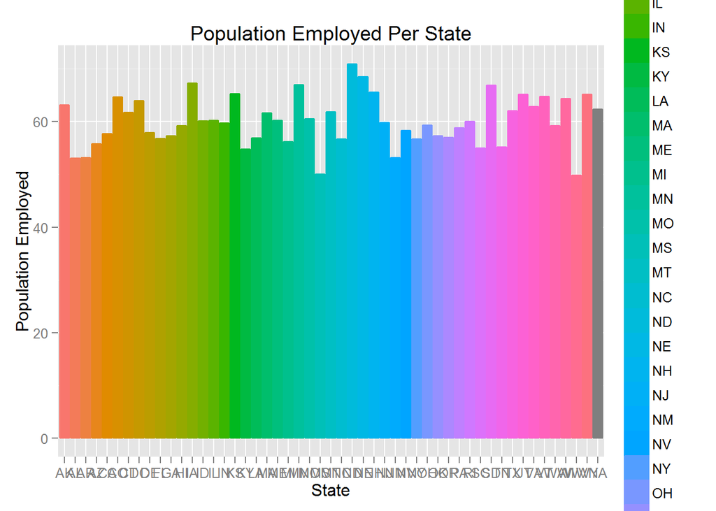

```r
source("../03 Visualization/Visualization3(2).R", echo=TRUE)
```

```
##
## > ggplot(data = tmp6, mapping = aes(x = STATE, y = count,
## +     color = STATE, fill = STATE)) + geom_bar(position = "dodge",
## +     stat = "identity" .... [TRUNCATED]
```

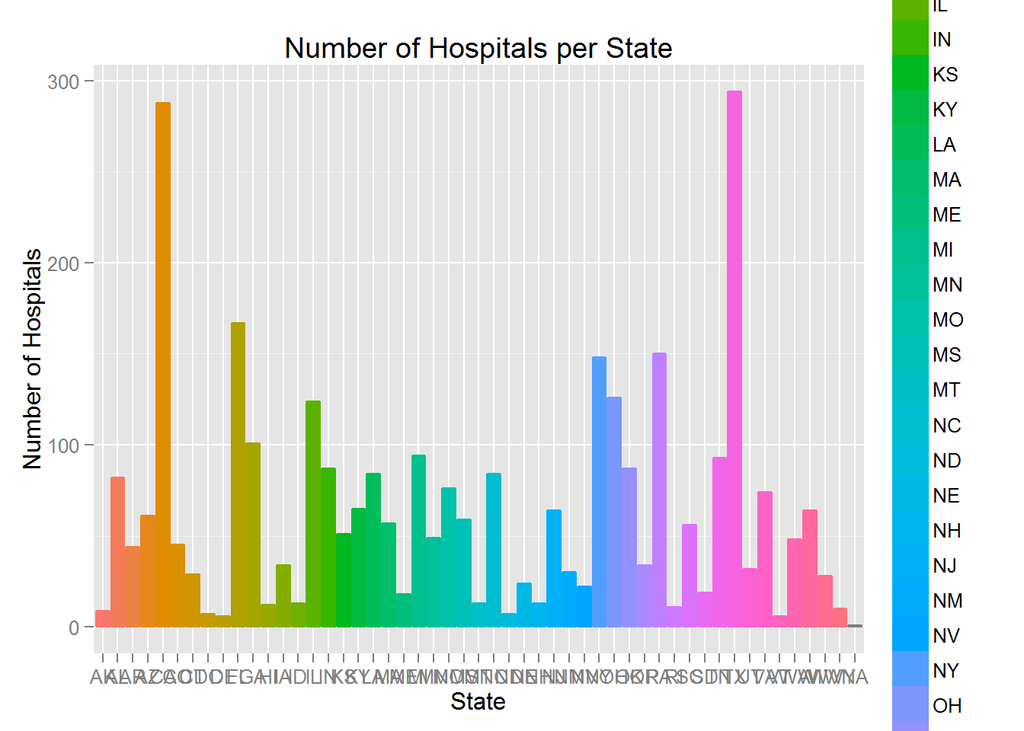

```r
source("../03 Visualization/Visualization3(3).R", echo=TRUE)
```

```
##
## > ggplot(data = tmp6, aes(x = count, y = POP_EMPLOYED)) +
## +     geom_point(size = 4, shape = 21, fill = "green", colour = "green") +
## +     labs(titl .... [TRUNCATED]
```

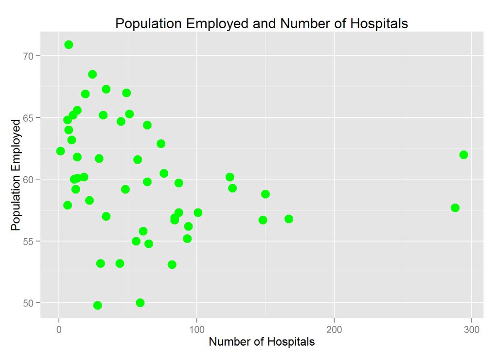